# Chinese Grand Prix Fantasy League Report

各位經理您好 and welcome to the race report for the 2025 Formula 1 Chinese Grand Prix, and the Fantasy League report of course. The Chinese Grand Prix is now firmly back on the calendar and hosting another sprint race. After the spontaneous fires last year, we were rather expecting some level of chaos this weekend, but the question is, did we get any?

## The News

### Team Radio Drama

Ferrari had a torrid weekend in Australia, finishing eighth and tenth at the season opener after such hype in preseason. Their efforts were not helped by their, seemingly never ending, team radio embarrassments. Leclerc's radio in particular has drawn quite a lot of attention on social media, with the Monegasque reporting a leak in the cockpit, a leak of water, and his engineer responding that it must be the water. Clearly, this is a translation issue, but it doesn't help things, and Leclerc is hyper aware of the memes surrounding his team. Despite this, it's actually Lewis' radio messages that have drawn in a lot of media attention. Lewis was quite overly polite and timid in his first race for the Scuderia, telling his engineer that he wants to be "left alone please" or "leave me to it please", repeatedly. Lewis responded to this attention by pointing the finger at Max Verstappen, who is famously harsh to his race engineer GP when things aren't quite going the way either of them hoped. It certainly was a harsh awakening to the problems with Ferrari race engineering for the 7-time champion, but it has also drawn the British fans into the drama, for perhaps the first time. This is their first time paying attention to the radio messages properly, because it affects their driver. As such, it seems to be the only thing people are focusing on in the build up to the Chinese Grand Prix, with Ferrari looking to turn their form around this weekend.

### Lawson Under Scrutiny

Liam Lawson has perhaps had the hardest ride of the rookies in 2025, even though we have only had one race, and nearly all of them DNFd the first race. Hadjar crashed on the opening lap, but despite a few distasteful comments from Helmut Marko in the media, the focus has really been on the young Kiwi. There's good reason for this too. It is well known that the second Red Bull seat has been a difficult beast to tame since the departure of Daniel Ricciardo at the end of 2018, though perhaps it has always been something of a difficult car to drive, with many second drivers struggling or departing from the role early. Since Ricciardo, Red Bull have employed Pierre Gasly, Alex Albon, Sergio Perez, and now Lawson, who have all struggled. It was Albon who famously described the problem as a sensitivity issue, with the car clearly designed around Max and his love of a sensitive front end, cheeky. The problem gets worse throughout the season, so for Lawson to be struggling off the bat, is not a good sign. But why has Lawson received so much media attention? Well, it isn't a secret, the drivers are very aware of the apparent curse of that seat, and Lawson himself is quoted as saying that it is HIS job to get on top of the beast, and that he's not here to make friends, he's here to win. He himself has hyped his own skills in this area, so to hit the ground in Australia with a Q1 elimination and a DNF, is not a good omen. Horner backed his two rookie drivers publicly, but we also saw this with Sergio Perez. The problem for Lawson is that he's in the big leagues at that team, and he also doesn't bring a huge amount of sponsorship money or crowd support for Red Bull to continue to let him wallow at the back, unlike his predecessor. If Lawson can't turn this around, we know how brutal Red Bull can be.

### FIA Deflections

The FIA released a statement between the Australian and Chinese Grand Prix weekends that new "tougher" texts would be introduced for the rear wing deflection test. It has long been the case that teams are required to run a rear-facing T-cam and provide target on the rearward aerodynamic components for the camera to monitor, but during practice in Australia all teams were requested to use the cameras so that the FIA could monitor throughout the session. The upper rear wing is the area of concern, following accusations that certain teams are allowing the rear wing end plates to deform and create a miniature DRS effect. The FIA are perfectly within their rights to introduce a new set of tests, and although all cars were deemed to be legal in Australia, they have upped the weight to 75 kg and the rear wing mainplane must not vary by more than 2 mm. It is speculated, though not confirmed by anybody of authority, that McLaren are the main offenders following their investigation at the Azerbaijan Grand Prix last year. I don't expect this to have a major effect on the papaya cars, who seem to have a comfortable advantage in the early part of the this season.

### A True Legend

It is with sadness that F1 reported the death of former team owner, racing driver, and TV presenter Eddie Jordan on Thursday. The Irish legend passed away at the age of 76 following a short but aggressive fight with cancer. I will never be able to do Eddie the justice he deserves with any kind of obituary, but F1 put out a phenomenal tribute to a man who truly embodied everything this sport stands for. My memory of Eddie spans his team ownership era, with the bright yellow Jordans sporting all kinds of animals on the front, and as a TV broadcaster in the later years. The man truly could get an answer out of just about anyone. He will be sorely missed.

## Grand Prix Report

Alright, plenty to talk about this weekend since it was the first of the six sprint weekends, so let's get into it.

### Sprint Qualifying

Sprint qualifying is still a bit of a weird one for me, it always feels like there shouldn't be this much of a gap between SQ3 and the sprint race, but it directly replaces FP2, so that's just the way it is. It almost feels like they should be back to back.

SQ1 is completed on the medium tyres, with many teams then forced to do a double warm-up lap to bring the temperatures and pressures in the optimum window. It also means that track evolution was quite extreme throughout the session. SQ1 saw the elimination of Doohan, Gasly, Ocon, Hulkenberg, and Lawson. The Red Bull man just couldn't get the car into the right window and finished last of the qualifiers when the eyes of the world media is upon him, not good enough. Both Alpines were apparently blocked during their fast runs, but as far as I can tell, there were no penalties handed out, so perhaps this is just an excuse they are using.

The fight for pole became clear in SQ2 as the McLarens, Ferraris, and Max all seemed quick, Mercedes were showing signs of pace too, meaning it could have been a 7-way fight for pole, and those final SQ3 places were left for the remaining 8 drivers. Alonso, Bearman, Sainz, Bortoleto, and Hadjar weer all eliminated in this session, and praise where praise is due for Bearman and Bortoleto who both beat their more experienced teammates after some disappointing results in Australia.

SQ3 is the only session completed on softs and it's almost not quite long enough for two fast runs, if you're doing a double warm-up. The early blood went to the McLarens who both went to the top, but in the final push laps, it was Lewis Hamilton who put his Ferrari on pole, setting a new all-time lap record in the process. Piastri was the fastest of the McLaren runners with Norris aborting his final push lap, but it was Max Verstappen who lined up in second place ahead of Oscar. Leclerc lined up in fourth behind is teammate, followed by Russell, Norris, Antonelli, and Tsunoda who put in a good best-of-the-rest performance. Alex Albon managed ninth in the Williams which was a good effort, and Lance Stroll maintained his very average 2025 performances to round out the top ten.

### Sprint Race

I don't think anything waters the mouth of a modern F1 fan more than hearing the phrase "Lewis Hamilton lines up alongside Max Verstappen on the front row of the grid", hearing Crofty say that on the broadcast made the early morning start well worth it. With high tyre wear on offer for the weekend, teams were reluctant to run new mediums in the sprint race, with all 20 drivers opting for used mediums; used being quite a strong word there, most were around 4-6 laps old.

Hamilton's start was very reminiscent of 2021, the Ferrari man moving over aggressively to cover the reigning champ's line into turn 1 off, with Piastri trying to make a move round the Dutchman also. Leclerc managed to keep the Mercs behind him, while Lando Norris locked up in the first sector, ran wide, and dropped down to ninth place; it seems his poor starts weren't left in 2024 as he said. The race was something of a tyre-degradation experiment for the main race, with the key being to get clean air, maintain minimal slip, and not waste time trying to fight the driver ahead if you didn't have a clear advantage.

Norris reported that he was struggling a lot with his tyre wear, but his teammate didn't seem to be suffering as much and was able to get through on Verstappen to take second place. Similarly, George Russell was able to make a key move on Charles Leclerc to take fourth place, with the leading car having something of an advantage on tyre wear being the most important thing. As the two behind him fought hard, Hamilton pulled out his advantage and used his tyre management to extend his gap and eventually take the sprint win. Now many people were quick to say that this was his first win in only the second race of the season, but it's definitely fair to say his first time winning in red, and he did it in a classic Lewis way of leading from the front and pushing within the limits of the tyres. Weirdly, his teammate showed reasonable tyre wear too and was able to attack Russell in the dying stages, to no avail, but it still showed that the Ferrari tyre wear was actually pretty good.

Championship leader, Lando Norris was able to secure a point at the end of the race, overtaking Lance Stroll who seems to be putting in some reasonable performances at the moment. So Lewis, Piastri, Verstappen, Russell, Leclerc, Tsunoda (first points of the season), Antonelli, and Norris to secure the points. Weirdly, Williams were fined after the race for a camera infringement, but they later appealed and worked with the FIA to find what the issue was. I can't seem to tell if the fine was cancelled or refunded. Lawson managed to fight his way to fourteenth, but was aided by a collision between the two Kick Saubers and Doohan at the final corner.

### Qualifying Report

Straight back into the action a few hours later, then, for qualifying. Many expected the sprint race sessions to be an indicator for the race sessions, but with setup changes now allowed and tyre wear more of an issue than many teams expected, teams opted to change their setup to focus more on race pace and tyre preservation.

Back to the classic format and free choice of tyres then in Q1. The Saubers and the Astons battled it out in the early stages while Doohan had a little spin into the gravel, but it wasn't long before the pace of the McLarens came out and they both shot up to the top of the timing sheets. Verstappen also managed to set a pretty decent lap, meaning he didn't have to use another set of tyres and was able to sit out the session in the pits. Drivers eliminated in Q1 were Gasly, Bearman, Doohan, Bortoleto, and Lawson. Another session, another Liam Lawson elimination, and what makes it worse is that it was two qualifying sessions at the same track in different conditions where he has finished in last. Surprising to see Bortoleto not make it through, he's been putting in some reasonable performances in qualifying, and just needs to get on top of things in race trim.

With tyres at a premium, many of the top teams ran used tyres for the first run in Q2. Those who didn't, but looked to be struggling were Stroll, Ocon, Hadjar, Alonso, and Sainz, who were all in the drop zone as teams prepared for their final push laps. Norris went to the top of the table and decided to sit this one out, and it was a good call. Many many improvements in the final laps, so much so that Sprint winner Hamilton was almost eliminated in Q2. The drivers who were eliminated were Ocon, Hulkenberg, Alonso, Stroll, and Sainz. Carlos doesn't seem to be getting on top of that Williams as quickly as many imagined, I'm sure it'll click at some point soon, he's not exactly under performing, but he's also now wowing in the same way he has at Renault and Ferrari, more to come I hope. Alonso finally outperforming his teammate this season is not something that 2023 me thought he'd ever write, but here we are. Good laps from Hulkenberg and Ocon, but those cars are fundamentally lacking where it counts in China.

The early fast laps went in the favour of Oscar Piastri as McLaren seemed to have this one in the bag. Ferrari had lost their earlier pace, Verstappen seemed to be best of the rest, and Mercedes seemed unable to switch the tyres on with Russell reporting nothing but problems over the radio. Once again on the final laps, Norris made a mistake and aborted the lap, leaving his teammate to take pole, and he set a faster lap doing so and broke Hamilton's new record. Russell managed to switch the tyres on and secure second, ahead of the second McLaren and the reigning champion. Hamilton and Leclerc were fifth and sixth, ahead of Hadjar, Antonelli, Tsunoda, and ALbon. Once again the Racing Bull is looking like a great car, if only they had been able to convert to points in Australia.

### Race Report

Australia really was a banger of a race, not a nail biter like Abu Dhabi 21, or whatever year the German Grand Prix was where it rained and everyone kept going off at the last corner, but for a season opener, it was pretty good. China, on the other hand, was not all that interesting; there were things going on, but it was quite the tyre management Grand Prix. Piastri pinned Russell into turn one, which allowed Norris through for a McLaren one-two, and we thought finally we were going to get the Norris Piastri battle that we hoped for, but the Aussie seemed to have his teammate covered, with the second car suffering more with tyre wear anyway. This was pretty much the story throughout the race, as McLaren sort of pulled away from the rest of the field and maintained a steady gap throughout. The only real threat to their domination was Lando's brake pedal in the dying stages of the Grand Prix. Given one more corner, he might not have been on the podium, but for those papaya fans out there, he did and they claimed a solid one-two in the main race. It doesn't bode well for their team harmony later in the year though, if they've got both drivers capable of winning races and taking big points out of each other, screams Mercedes 2016 to me.

If Charles Leclerc was trying to hide that he's a little worried about his team favouring Lewis this season, he's doing a bad job of it. He ran over the kerb at turn 1 on the opening lap and hit the back of his teammate, dislodging the front wing endplate. This, however, didn't seem to deter him in anyway. He spent a large amount of the race faster than Lewis, complaining that he was being held up. They waited until after the first pit stop, when they probably should have replaced his front wing, before they swapped the cars round to allow the faster Leclerc through to attack Russell ahead. He was able to eventually catch up to the back of George towards the end of the race, as all the top teams attempted the one-stop, but it was to no avail. The weekend got much worse for the Ferrari team after the race, when Hamilton was disqualified for a rear skid infringement, which was 0.4 mm under the 9 mm minimum thickness. As if that wasn't enough, Leclerc was also disqualified for a minimum weight issue, with his Ferrari coming in 1 kg under the minimum weight after the fuel sample was taken. The FIA weigh the car as is, and then allowed Ferrari (as they would anyone) to replace the front wing with a like-for-like part, at both of these tests, the car passed, but when the fuel sample was taken, the car came in at 799 kg.

The double DSQ for Ferrari was pretty good new for some of the midfield teams who normally wouldn't get a shout at a good haul of points. Esteban Ocon finished the race behind Verstappen in fifth place after starting way down the order. Haas did a double one-stop on the alternate tyre compound and it really worked for them, teammate Bearman put the woes of Australia behind him to finish eighth behind Antonelli and Albon, who both put in reasonable performances but were well off the pace of the lead cars. Lance Stroll continues his reasonable run of form to finish in ninth, ahead of Carlos Sainz who benefits from the Ferrari issues to secure his first points in a Williams. Comically, the Leclerc DSQ promoted Sebastian Vettel back to the top of the all-time Ferrari points-scorers list, with the two old teammates almost equal on points for the Scuderia.

It really was a race of attrition on the tyres, but one team that managed to take their good pace and throw it away on a gamble for more points was Racing Bulls. Both Tsunoda and Hadjar were running in decent points, and could have potentially finished fifth and sixth after the Ferrari DSQs, but decided to pit with 20 laps to go and put on a fresh tyres to chase down the Ferraris ahead. It didn't work for them and they both finished outside the points. Another race where their strategy has let them down, and it's really starting to be an issue. They have a car this year that should be cleaning up the points on the tail end of the leading four teams. But twice now, they have thrown it away over hero-strategies that, yes, have worked for them in the past. But they need to get out of that mentality. Speaking of underwhelming, Liam Lawson had a pretty average race; he managed to keep out of drama, but when your teammate is fighting for podiums, you have to do better than fourteenth across the line, twelfth after the disqualifications. Finally, Fernando Alonso DNFs another race in 2025, this time with brake issues. The Spaniard's rear brakes caught fire early in the race, and the double-world-champion was forced to retire early yet again.

## Fantasy League Scores

Scores for drivers/constructors in the current year's fantasy league, along with manager/team points, values, and statistics. Note: driver and constructor values are taken as the cost to enter the current race and are updated the week before the race.

## Lineup Scores

With such a busy weekend, there was plenty of opportunity for the drivers and teams to score a whole heap of points this weekend. Let's start off with the driver and team points.

Oscar Piastri is our winner this week, after securing a P2 in the sprint and a P1 in the race, the Aussie brings home 45 points ahead of teammate Lando Norris in second with 41 points, McLaren clearly the team to back this week. George Russell quietly secures a third place with 35 points ahead of reigning world champion Max Verstappen in fourth with 30. Mercedes rookie Kimi Antonelli rounds out the top five with 29 points. Another disappointing weekend for Fernando Alonso who finishes last with -16 points. He's joined down there by disqualified driver Charles Leclerc with -12. Another driver who received a weight-limit disqualification is Pierre Gasly, the Frenchman brought home -8 points. Lewis Hamilton is next, with a -1 points score in fourth place. Nico Hulkenberg rounds out the bottom five with an anonymous 2 points this week.

McLaren top the constructors standings this week with a huge 101 points. They are leaps ahead of Mercedes who just pip Red Bull to second, the pair scoring 69 and 67 points respectively. Ferrari suffer a huge blow this week with that double DSQ, the Scuderia suffering a loss of -23 points. Alpine are also in the negative this week, the French outfit only losing -6 points. Aston Martin round out the bottom three with 4 points.

Now that we've had more than one race, we can discuss the total points and the current championship standing now. Lando Norris leads the way, the Brit the first driver to reach triple figures this season, he's currently sitting on 100 points. Rookie sensation Kimi Antonelli is in a close fought second with his teammate Russell, the Mercedes duo have 61 and 60 points between them. Max Verstappen is hot on their heels in fourth with 59 points, and Oscar Piastri takes a leap up the table with 55 points in fifth. Fernando Alonso is firmly at the bottom after two negative weekly scores with -36 points. He's behind Gabriel Bortoleto and Carlos Sainz with -11 points, just below Jack Doohan and Isack Hadjar with -9 points. Pierre Gasly is a close fourth with -7 points, and Charles Leclerc has had a point-less season so far in fifth with 0.

McLaren lead the way in the constructors' championship with 172 points, after two very strong races that is quite some points haul. Mercedes are in second, quietly going about their business with 136 points. Red Bull are a distant third, with only one car bringing in big points, they sit on 86 points currently. Alpine are at the bottom of the table with -20 points, and are the only team with negative points at the moment. Aston Martin only have 5 points to their name, behind Ferrari with 13 points.

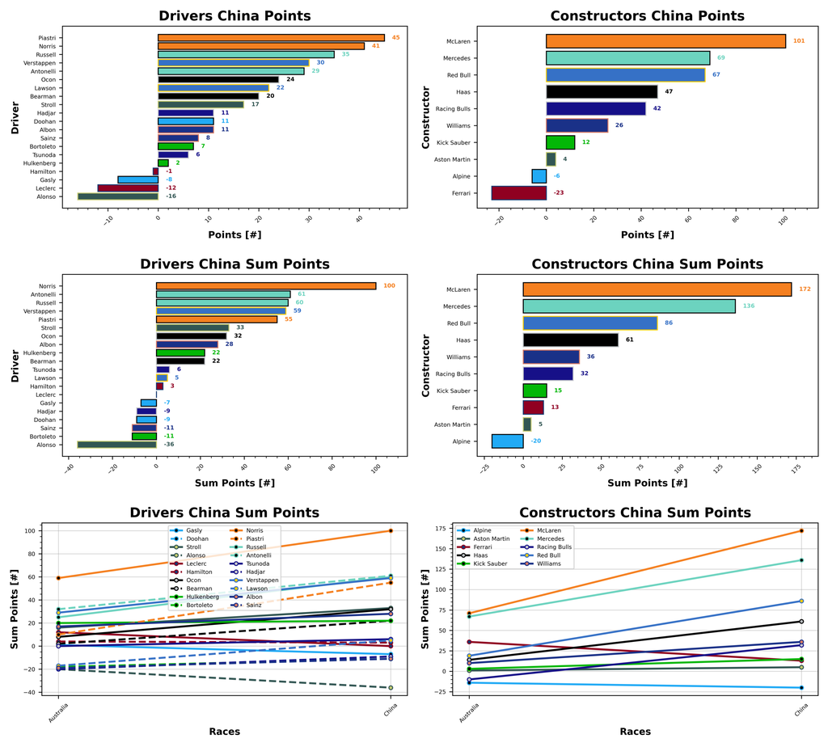

The driver market took a little bit of a mix up after the chaos of Australia, but Lando Norris is still the most expensive driver on the grid with a value of $29.3. Max Verstappen is still holding his value quite well at $28.5. The Ferrari duo are next with values $25.6 and $23.9. Oscar Piastri rounds out the top five with a value of $22.7. The cheapest driver this week was Gabriel Bortoleto with a value of $5.4. Isack Hadjar is a little bit more expensive with a value of $5.6, just below Oli Bearman at $6.1. Jack Doohan is next at $6.6, and Nico Hulkenberg rounds out the cheap five with a value of $7.0.

McLaren increase their value from last week, topping the table at $30.3. Then it's Ferrari who maintain at $27.4 and Red Bull who jump up to $25.1. Kick Sauber are your cheapest team of the week, dropping value to $5.6, then Racing Bulls with a value of $7.4, and Haas at $7.6.

All values are in $M.

Alonso is by far the worst performing driver of the season so far, with a positive scoring percentage of 0%. There's a good balance between those that are 100% positive and 50% at the moment too after two races. Alpine are your worst team of the season so far, having a 0% positive scoring rate.

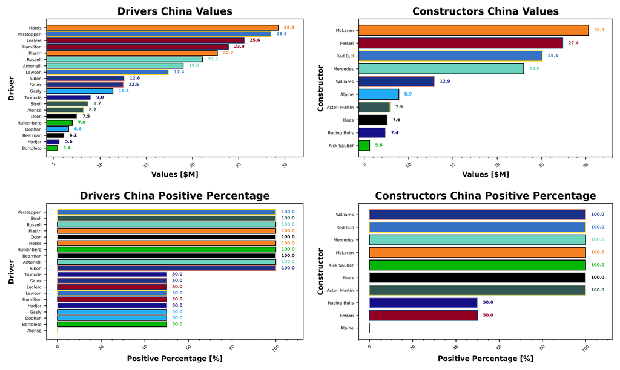

Lando Norris leads the way on the scoring front, with an average of 50 points per race, followed by Antonelli with 30.5 points per race and George Russell with 30 points per race. Verstappen and Piastri round out the top five with 29.5 and 27.5 points per race, respectively. Alonso is by far the worst on the grid at the moment with an average of -18 points per race, then Bortoleto and Sainz with -5.5 points per race, followed by Doohan and Hadjar with -4.5 points per race. Gasly and Leclerc round out the bottom five with -3.5 points per race and 0 points per race, respectively.

McLaren top the table with 86 points per race, followed by Mercedes and Red Bull with 68 and 43 points per race. Alpine are the only negative team with -10 points per race, followed by Aston Martin with 2.5 points per race, and Ferrari with 6.5 points per race.

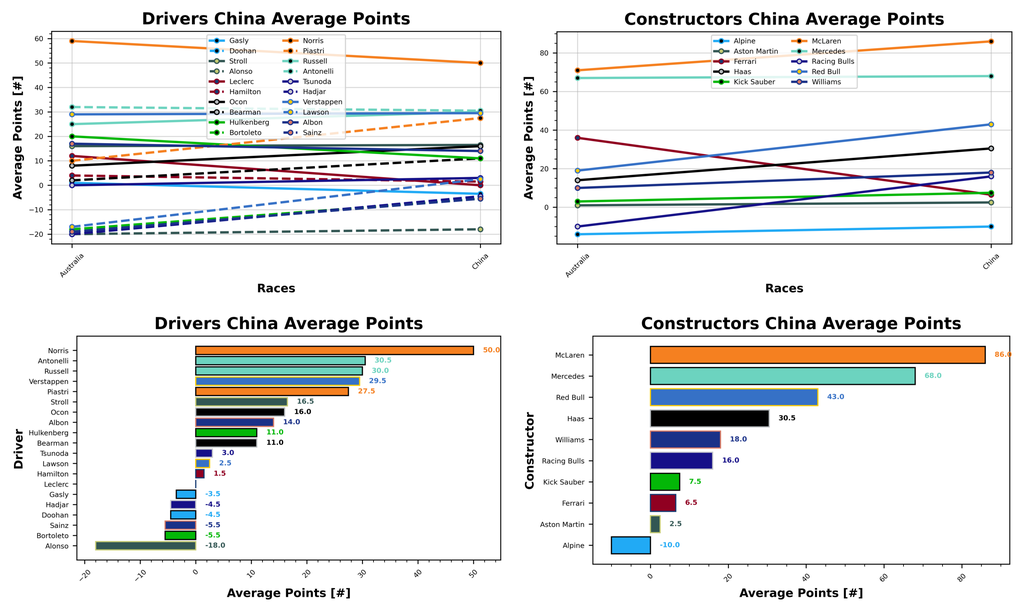

Your driver of the week was none other than Oliver Bearman, who brought home an impressive 3.28 ppm. He's followed up by his far more experienced teammate Esteban Ocon with 3.2 ppm. Race winner Oscar Piastri is some way off in third place with 1.98 ppm, closely followed by Isack Hadjar with 1.96 ppm. Rounding out the top five is Lance Stroll with 1.95 ppm. Alonso brings home a disappointing -1.95 ppm, followed by Gasly with -0.7 ppm. Charles Leclerc is next with -0.47 ppm, with his teammate next up with -0.04 ppm. Nico Hulkenberg rounds out the bottom five with 0.29 ppm.

Haas top the constructors' table too, with a whopping 6.18 ppm, ahead of Racing Bulls with 5.68. McLaren are a distant third with 3.33 ppm. Ferrari are your worst team of the week with -0.84 ppm, followed by Alpine with -0.67 ppm and Aston Martin with 0.51 ppm.

ppm = points per million ($).

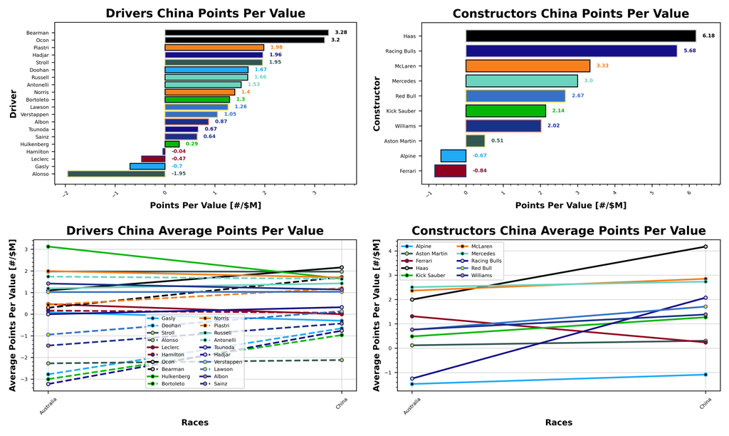

### Manager Scores

Now let's take a look at who came out on top this week. Josh takes the early sprint king victory with their team HSBC Jaguar Racing, bringing in 283 points. Nothing too mega for a sprint weekend there, but a reasonable score. Championship leader Sebastian and Bridgestone Toro Rosso F1 are in second with 277 points, ahead of Madlen and Push, Push - Box Now Too in third with 276. Val is next with Its 'odinge' in fourth place with 271, closely followed by Stefanus and Haryanto in fifth with 270. A very tight top five indeed. Not as many negative points as I would have thought for a triple DSQ race weekend, but it is Val and Limoncello44 leading the way at the bottom of the grid with -27 points, just ahead of Phil and BMW Should Be Here with -25 in second place. Chloe is next up with Mickeys Roadster Racers in third with -4 points. Will and Dinoco Piston Cup Champs are in fourth place with 0 points, and an unfortunate double bottom five appearance from Phil with BMW Motorrad with 19 points to round out the bottom teams this week.

Josh sits at the top of the managers' table this week with 248.67 points across their teams. They're closely followed by Sebastian with 227.6 and Finn with 223. Then comes Stefanus with 213, and Madlen rounds out the top five with 198. Your worst manager of the week was Phil with a lowly 65.67 points, behind Chloe with 82, Will with 112.33, Pete with 121, and Valerie with 125.33.

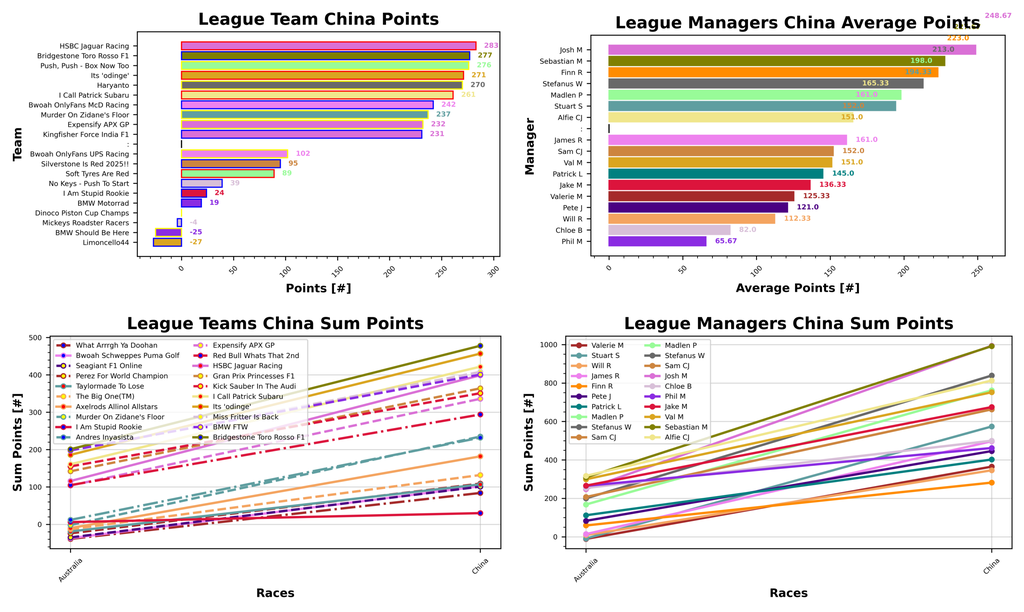

Sebastian still leads the way in the championship standings with 478 points with their team Bridgestone Toro Rosso F1. Val moves up to second with Its 'odinge' sitting on 457 points. Then it's rookie manager Alfie with I Call Patrick Subaru in third place with 422 points. Chloe and Miss Fritter Is Back are in fourth with 408 points, and Phil rounds out the top five with BMW FTW with 401 points. Phil is also in last place with their team BMW Should Be Here with -1 points, I agree BMW should be there. Val is next with Limoncello44 with only 7 points, behind Chloe and Mickeys Roadster Racers with 16 points. Jake is next with I Am Stupid Rookie, only managing 30 points this season so far. Rounding out the bottom five is Will and Dinoco Piston Cup Champs with 32 points.

Still early in the season but we do have to talk about the big movers and big losers in the field. This week it's Stuart taking the top two biggest moves with 21 and 18 places gained for Murder On Zidane's Floor and Andres Inyasista, respectively. James and Bwoah OnlyFans McD Racing also making some big steps this week with 17 places gained. Madlen and Push, Push - Box Now Too move up 16 places. Josh and Kingfisher Force India F1 round out the top five with 14 places gained. Phil and Val are our biggest losers this week, dropping 17 places with BMW Motorrad and Limoncello44. Phil makes it twice into this report with BMW Should Be Here also dropping 14 places along with Madlen and Soft Tyres Are Red. Alfie and Cucumberpotatolamborghini are tied with Will and Dinoco Piston Cup Champs, Pete and Monaco Barrier Testers, and Chloe with No Keys - Push To Start, all dropping 13 places. Rounding out the bottom... erm... four, is Chloe and Valerie with their teams Mickeys Roadster Racers and Stroll To The 18th both dropping 10 places.

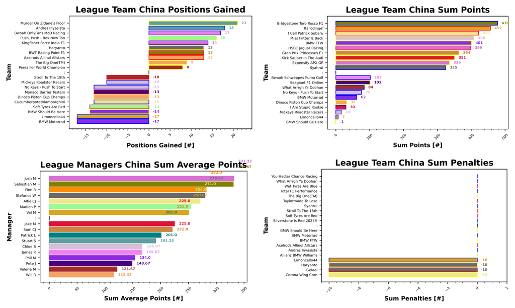

Oliver Bearman was your most selected driver this week, the young Haas man making an appearance 21 times in your teams. Tsunoda, Hadjar, and Alonso are also popular choices with 19 selections. Hulkenberg sits in third with 18 selections, ahead of Ocon and Sainz with 17 and 16 selections, respectively. Lawson made it into none of your teams this week, swiftly dropped by all of you. Russell is only out there twice, behind reigning champion Max Verstappen with 5. Kimi Antonelli is next with only 6 of you choosing the second place in the league driver. Gasly rounds out the bottom five with only 8 selections.

McLaren were your most selected team this week with 18 of you choosing the Woking outfit, ahead of Ferrari with 16 - ouch, and Haas with 13. Red Bull are your least selected team with only 3 devote fans choosing them, followed by Alpine with 4 and Mercedes with 6.

Lando Norris is flavour of the week yet again with your double scorers, he's been DRS Boosted 11 times this week, ahead of teammate Piastri and Hamilton with 7 each. Leclerc and Bortoleto round out the top three with 4 Boosts. The first sprint race brings with it the first perks used, this week we had 9, yes 9 of you using your no negative tokens to good effect, we had 2 limitless tokens and 2 auto pilots also.

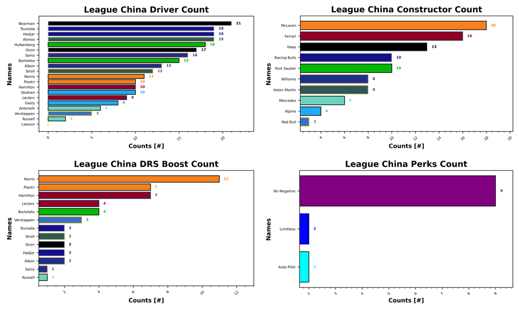

## Prizes

I have now updated the prizes plotting for my code and we should be able to track the season long prizes with ease. So without further adieu, let's take a look at what is currently in play this season.

### Championship

| Prize Name | Prize Value | Terms |
| --- | --- | --- |
|  | (%) |  |
| Champion of the World | 20 | Awarded to the top scorer in the league at the end of the season |
| If You're Not First, You're Last | 10 | Awarded to the second place scorer in the league at the end of the season |
| Alpine Podium | 5 | Awarded to the third place scorer in the league at the end of the season |
| Above Par | 20 | Awarded to the lowest scorer in the league at the end of the season, commonly referred to as the Golf League |

### Achievements

| Prize Name | Prize Value | Terms |
| --- | --- | --- |
|  | (%) |  |
| Cost Cappen | 5 | Highest average points per value at the end of the season |
| Sprint King | 5 | Highest score across the sprint races (China, Miami, Belgium, United States, Brazil, Qatar) |
| Flavio Controls Every Millimeter | 5 | Manager wide substitution count, highest wins |
| The Triple Header | 5 | Highest score across the triple header races (Japan, Bahrain, Saudi Arabia, Emilia Romagna, Monaco, Spain, Las Vegas, Qatar, Abu Dhabi) |
| I Forgot I Was Taking Part | 5 | Highest score in the first part of the season |
| Zak's Master Plan | 5 | Lowest score in the second half of the season |
| Mega Driver | 5 | Highest Extra DRS token score |
| The Continental | 5 | Highest score across all 5 continents, Mexico classed as South America for inclusion only (Australia, Canada, Great Britain, Azerbaijan, Mexico) |

### Spot Prizes

| Prize Name | Prize Value | Terms |
| --- | --- | --- |
|  | (%) |  |
| The Ring | 1 | Highest score at the Austrian Grand Prix |
| Bottas Bowling | 1 | Highest score at the Hungarian Grand Prix |
| Daniel's Broken Hand | 1 | Lowest score at the Netherlands Grand Prix |
| The Tifosi | 1 | Lowest score at the Italian Grand Prix |
| Go For The Gap | 1 | Lowest score at the Singapore Grand Prix |

### Spot Prizes

We haven't had a spot prize yet, I will post about it when we have one!

### Cost Cappen

If you're playing along this year, the highest average points per value is currently being led by Sebastian with Bridgestone Toro Rosso F1, sitting on 2.4002 points per million.

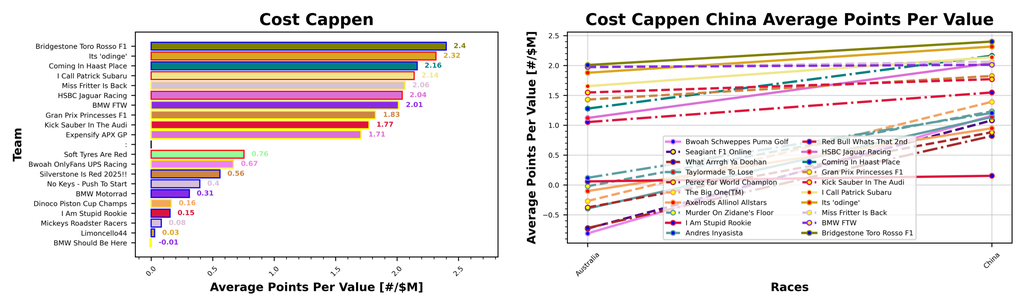

### Flavio Controls Every Millimeter

Flavio does indeed control every millimeter, and so far so does Stefanus and Sam with 5 substitutes each in Syahrul and Gran Prix Princesses F1. It should be noted that barring any wildcard or limitless tokens, there are only 2 substitutions available so far, which tells me that there are some tokens being played in these teams already.

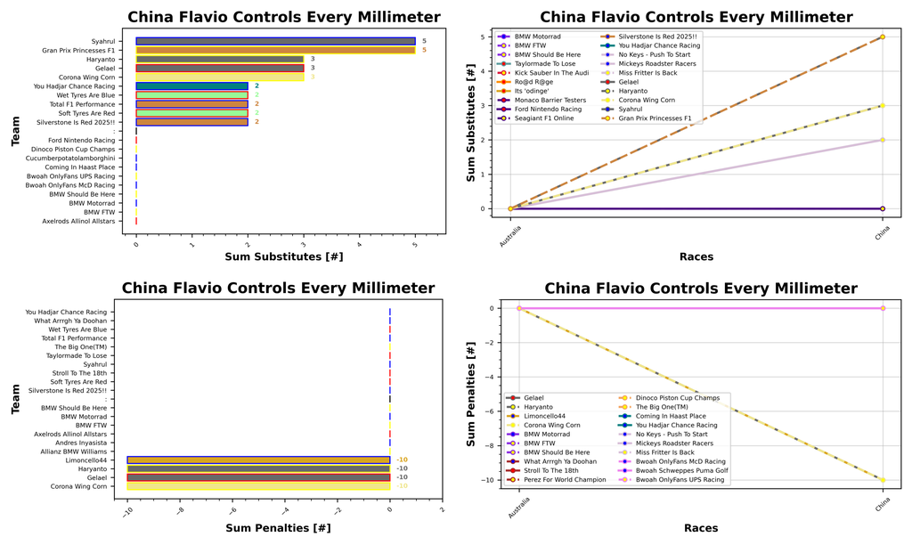

### Mega Driver

So far there have been no uses of the Extra DRS token. Check back later!

### Sprint King

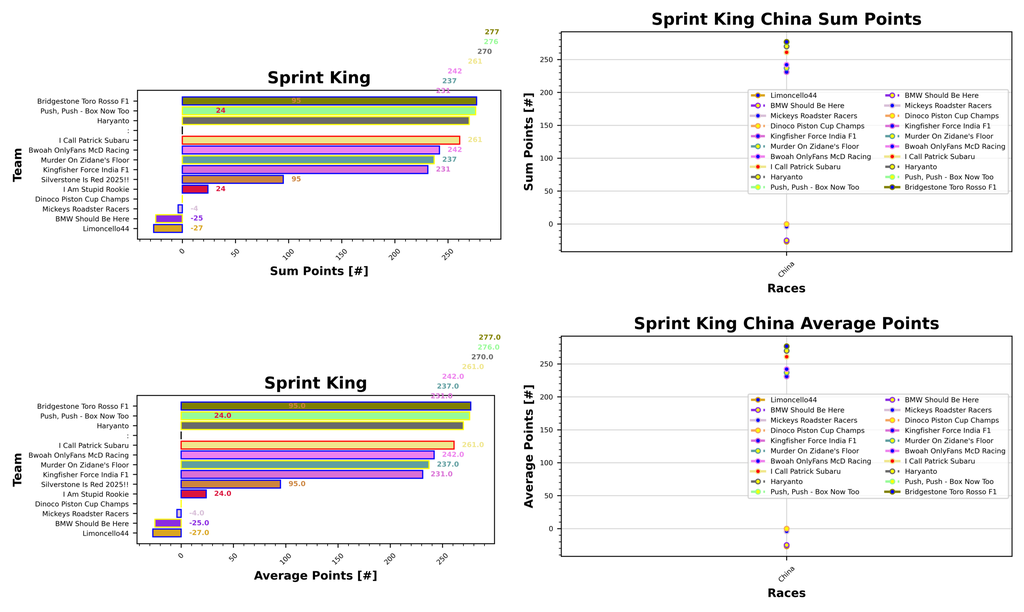

### The Continental

Sebastian is leading the way at the moment with Bridgestone Toro Rosso F1 and 201 points, ahead of Phil with BMW FTW with 198 and Miss Fritter Is Back, managed by Chloe, with 197. Their averages currently match their totals since we have only had 1 race from this category.

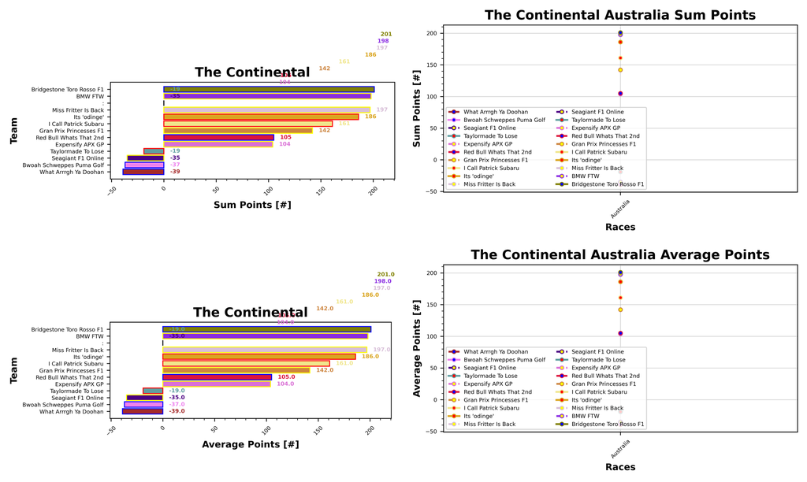

### The Triple Header

We haven't got to our first triple header yet, check back for more later!

### I Forgot I Was Taking Part

Sebastian and Bridgestone Toro Rosso F1 is currently leading the way with 478 points, ahead of Val and Its 'odinge' with 457 points. Alfie and I Call Patrick Subaru is next with 422 points. Currently they are averaging 239, 228.5, and 211 points per race, respectively.

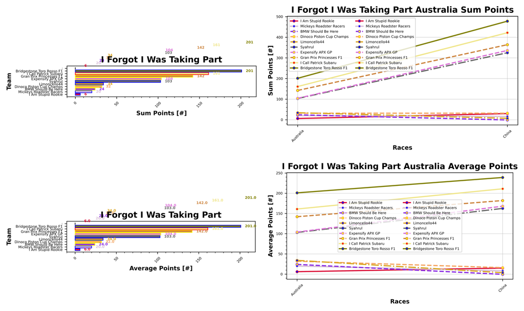

### Zak's Master Plan

Check back after the season break!

## F1 Predict

F1 predict time, I haven't quite yet sorted the plotting out for this one yet since I did my big overhaul middle of last year when everything started getting bit crazy, so bare with on the graphs for this one, I apologize. Stuart took the victory this week with 76 points scored, ahead of new entry "Palm Up In The Pits" with 69, and Pierce with 65 points. Josh was in fourth with 31 points, and Phil and Matty forgot or scored 0.

## Next Up

Next up is the Japanese Grand Prix in just over a week, and it marks the first of our triple headers this year, with Japan, Bahrain, and Saudi Arabia just around the corner. There also appears to be some news going on with Red Bull so it should be quite a spicy one for sure. Best of luck to you all.